# Exploring Diabetes Data through Unsupervised Learning: PCA and Clustering Analysis

Boning Liu

12-04-2024

# 1 Introduction

Unsupervised learning is a versatile data science technique used to uncover hidden patterns and structures in datasets without predefined labels or target outcomes. This assignment leverages two key unsupervised learning methods: Principal Component Analysis (PCA) and Clustering.

The primary objectives of this assignment are:

1. To explore and understand the structure of the dataset through comprehensive Exploratory Data Analysis (EDA).
2. To reduce the dimensionality of the dataset using PCA, retaining most of the variability in the data while simplifying its complexity.
3. To identify natural groupings or clusters within the data using clustering techniques.

## 1.1 Data Set

The dataset chosen for this assignment is the Diabetes Dataset, which contains information related to diabetes prediction based on a variety of medical measurements. This dataset is suitable for unsupervised learning tasks due to its size and the presence of multiple numerical variables.

Dataset Characteristics:

Source: Kaggle

Number of Observations: 768

Variables: 8 numerical variables and 1 categorical variable (Outcome)

Variables Description:

**Pregnancies**: Number of times the patient has been pregnant. (**Numerical**)

**Glucose**: Plasma glucose concentration after a 2-hour oral glucose tolerance test. (**Numerical**)

**BloodPressure**: Diastolic blood pressure (mm Hg). (**Numerical**)

**SkinThickness**: Triceps skinfold thickness (mm). (**Numerical**)

**Insulin**: 2-hour serum insulin (mu U/ml). (**Numerical**)

**BMI**: Body mass index (weight in kg/(height in m)^2). (**Numerical**)

**DiabetesPedigreeFunction**: A function that scores the likelihood of diabetes based on family history. (**Numerical**)

**Age**: Age of the patient (years). (**Numerical**)

**Outcome**: Binary categorical variable indicating diabetes diagnosis (1 for positive, 0 for negative). (**Categorical**)

This dataset is well-suited for:

1. Analyzing correlations and variability across numerical features.
2. Applying PCA to reduce dimensionality and visualize key components.
3. Using clustering algorithms to group similar observations and uncover hidden patterns.

### 1.1.1 Importing the Data and Handling Missing Values

```r
# Load necessary libraries
library(tidyverse)
library(ggplot2)
library(corrplot)

# Load the dataset
data <- read.csv("diabetes.csv")

# View the first few rows
head(data)
```

```
  Pregnancies Glucose BloodPressure SkinThickness Insulin  BMI
1           6     148            72            35       0 33.6
2           1      85            66            29       0 26.6
3           8     183            64             0       0 23.3
4           1      89            66            23      94 28.1
5           0     137            40            35     168 43.1
6           5     116            74             0       0 25.6
  DiabetesPedigreeFunction Age Outcome
1                    0.627  50       1
2                    0.351  31       0
3                    0.672  32       1
4                    0.167  21       0
5                    2.288  33       1
6                    0.201  30       0
```

Missing values represented as zeros in key variables (e.g., Glucose, BMI, Insulin) were addressed by replacing them with the mean of the respective variables. This imputation method preserves the dataset size while maintaining statistical consistency for downstream analyses.

```r
# Replace zeros with NA for relevant columns
data_cleaned <- data %>%
  mutate(
    Glucose = ifelse(Glucose == 0, NA, Glucose),
    BloodPressure = ifelse(BloodPressure == 0, NA, BloodPressure),
    SkinThickness = ifelse(SkinThickness == 0, NA, SkinThickness),
    Insulin = ifelse(Insulin == 0, NA, Insulin),
    BMI = ifelse(BMI == 0, NA, BMI)
  )

# Impute missing values with the mean
data_imputed <- data_cleaned %>%
  mutate(
    Glucose = ifelse(is.na(Glucose), mean(Glucose, na.rm = TRUE), Glucose),
    BloodPressure = ifelse(is.na(BloodPressure), mean(BloodPressure, na.rm = TRUE), BloodPressure),
    SkinThickness = ifelse(is.na(SkinThickness), mean(SkinThickness, na.rm = TRUE), SkinThickness),
    Insulin = ifelse(is.na(Insulin), mean(Insulin, na.rm = TRUE), Insulin),
    BMI = ifelse(is.na(BMI), mean(BMI, na.rm = TRUE), BMI)
  )

# Check for remaining missing values
colSums(is.na(data_imputed))
```

```
             Pregnancies                  Glucose            BloodPressure
                       0                        0                        0
           SkinThickness                  Insulin                      BMI
                       0                        0                        0
DiabetesPedigreeFunction                      Age                  Outcome
                       0                        0                        0
```

# 2 Part I

# 3 EDA

## 3.1 Summary Statistics

```r
# Summary of the imputed dataset
summary(data_imputed)
```

```
  Pregnancies        Glucose       BloodPressure    SkinThickness
 Min.   : 0.000   Min.   : 44.00   Min.   : 24.00   Min.   : 7.00
 1st Qu.: 1.000   1st Qu.: 99.75   1st Qu.: 64.00   1st Qu.:25.00
 Median : 3.000   Median :117.00   Median : 72.20   Median :29.15
 Mean   : 3.845   Mean   :121.69   Mean   : 72.41   Mean   :29.15
 3rd Qu.: 6.000   3rd Qu.:140.25   3rd Qu.: 80.00   3rd Qu.:32.00
 Max.   :17.000   Max.   :199.00   Max.   :122.00   Max.   :99.00
    Insulin           BMI        DiabetesPedigreeFunction      Age
 Min.   : 14.0   Min.   :18.20   Min.   :0.0780           Min.   :21.00
 1st Qu.:121.5   1st Qu.:27.50   1st Qu.:0.2437           1st Qu.:24.00
 Median :155.5   Median :32.40   Median :0.3725           Median :29.00
 Mean   :155.5   Mean   :32.46   Mean   :0.4719           Mean   :33.24
 3rd Qu.:155.5   3rd Qu.:36.60   3rd Qu.:0.6262           3rd Qu.:41.00
 Max.   :846.0   Max.   :67.10   Max.   :2.4200           Max.   :81.00
    Outcome
 Min.   :0.000
 1st Qu.:0.000
 Median :0.000
 Mean   :0.349
 3rd Qu.:1.000
 Max.   :1.000
```

After imputation, missing values represented as zeros were replaced with meaningful averages:

- **Glucose**, **BloodPressure**, **SkinThickness**, **Insulin**, **BMI**: Minimum values are now biologically plausible (e.g., **Glucose**: 44, **BloodPressure**: 24). Central tendencies remain consistent, with median values close to the original.
- **Pregnancies**, **DiabetesPedigreeFunction**, **Age**, **Outcome**: No changes, as these variables did not have missing values.
- The dataset now contains complete data, ensuring readiness for PCA and clustering analysis.

## 3.2 Analysis of Target Variable Distribution

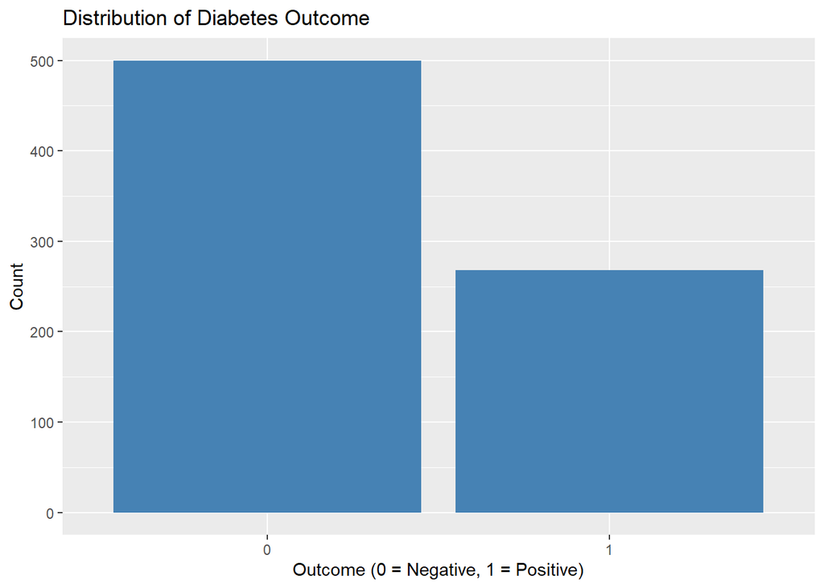

```r
library(ggplot2)

# Bar plot for target variable 'Outcome'
ggplot(data_imputed, aes(x = factor(Outcome))) +
  geom_bar(fill = "steelblue") +
  labs(title = "Distribution of Diabetes Outcome", x = "Outcome (0 = Negative, 1 = Positive)", y = "Count")
```

The bar plot shows the distribution of the **Outcome** variable:

## 3.3 Distribution of Key Predictors

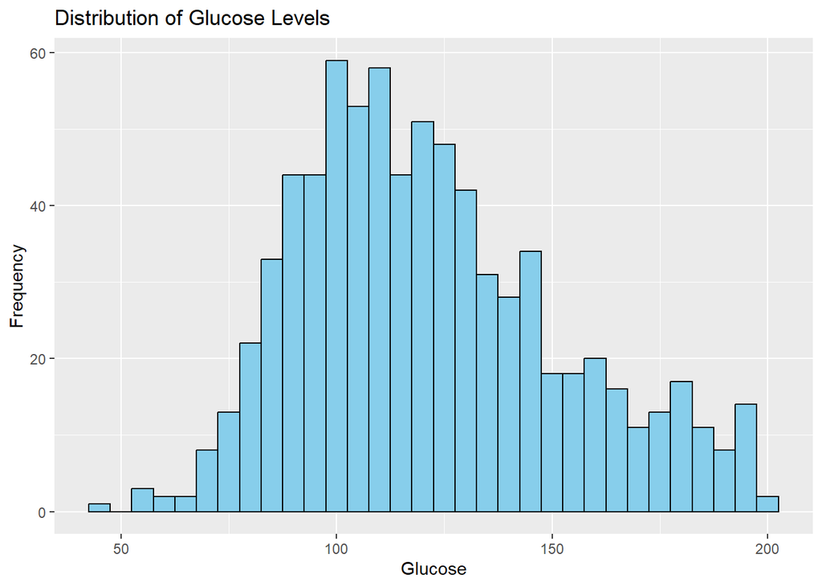

```r
# Histograms for key numerical variables
ggplot(data_imputed, aes(x = Glucose)) +
  geom_histogram(binwidth = 5, fill = "skyblue", color = "black") +
  labs(title = "Distribution of Glucose Levels", x = "Glucose", y = "Frequency")
```

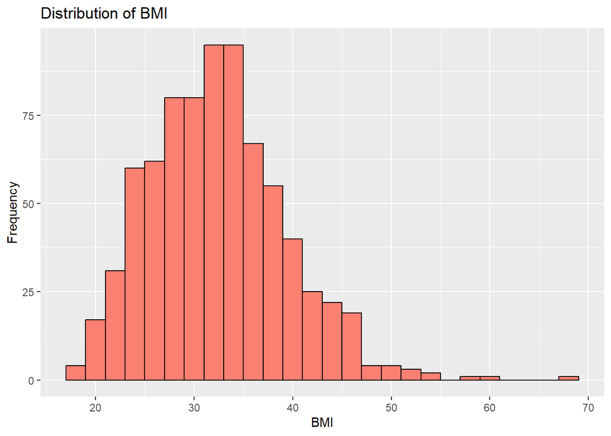

```r
ggplot(data_imputed, aes(x = BMI)) +
  geom_histogram(binwidth = 2, fill = "salmon", color = "black") +
  labs(title = "Distribution of BMI", x = "BMI", y = "Frequency")
```

**Glucose Levels**

- The histogram for **Glucose** shows a right-skewed distribution, with most values clustered between 80 and 140.
- A peak is observed around 100–120, indicating a concentration of individuals with moderate glucose levels.
- There are fewer instances of very low (below 60) or very high (above 160) glucose levels.

**BMI**

- The histogram for **BMI** exhibits a roughly normal distribution with a peak around 30.
- Most BMI values fall between 20 and 40, with fewer cases above 40.
- A few outliers exist with BMI values over 50, but they are rare.

## 3.4 Box Plots by Outcome

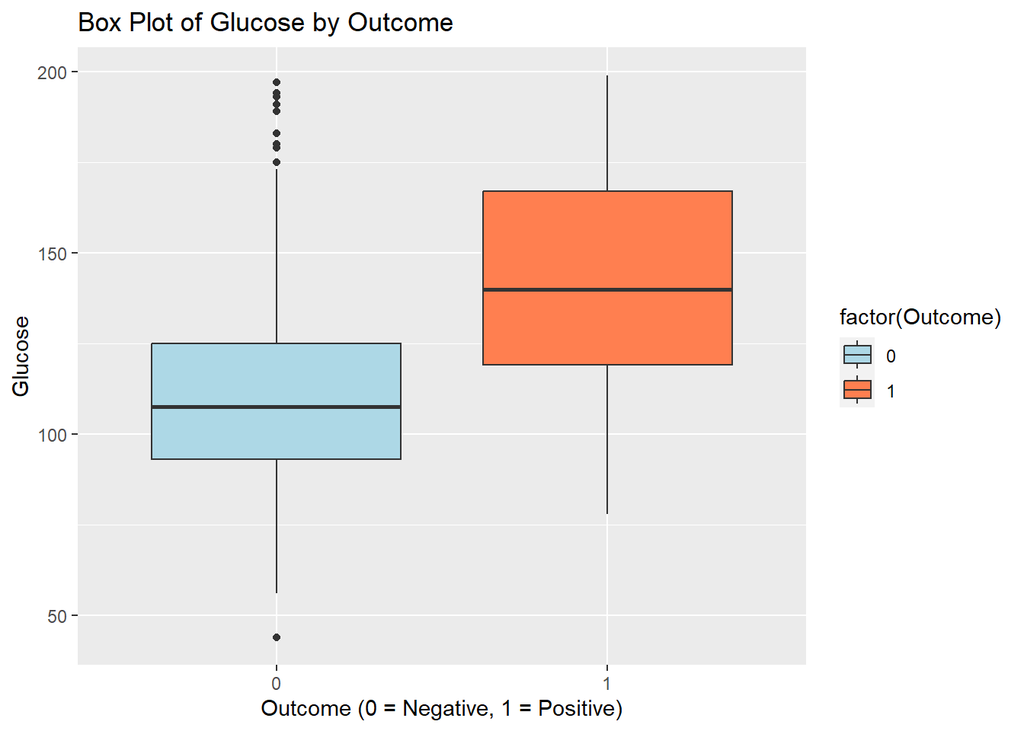

```r
# Box plot of 'Glucose' by 'Outcome'
ggplot(data_imputed, aes(x = factor(Outcome), y = Glucose, fill = factor(Outcome))) +
  geom_boxplot() +
  labs(title = "Box Plot of Glucose by Outcome", x = "Outcome (0 = Negative, 1 = Positive)", y = "Glucose") +
  scale_fill_manual(values = c("lightblue", "coral"))
```

**Negative Outcome (0):**

- The median glucose level is around 105.
- The interquartile range (IQR) is narrower compared to the positive group, indicating less variability.
- Several outliers exist on the higher end, but most glucose levels are within a lower range.

**Positive Outcome (1):**

- The median glucose level is noticeably higher, around 140.
- The IQR is wider, indicating more variability in glucose levels among individuals diagnosed with diabetes.
- Glucose levels in this group are generally higher compared to the negative group, with no significant low outliers.

# 4 PCA

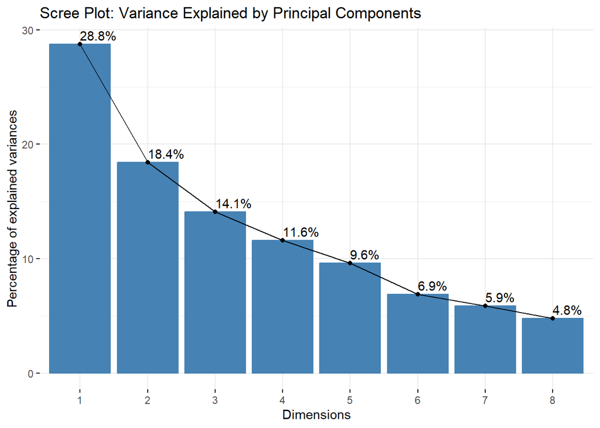

```r
# Load necessary libraries
library(ggplot2)
library(FactoMineR)
library(factoextra)

# Step 1: Standardize the data (numerical variables only)
data_scaled <- scale(data_imputed[, c("Pregnancies", "Glucose", "BloodPressure",
                                      "SkinThickness", "Insulin", "BMI",
                                      "DiabetesPedigreeFunction", "Age")])

# Step 2: Perform PCA
pca_result <- PCA(data_scaled, graph = FALSE)

# Step 3: Scree Plot
fviz_screeplot(pca_result, addlabels = TRUE,
               title = "Scree Plot: Variance Explained by Principal Components")
```

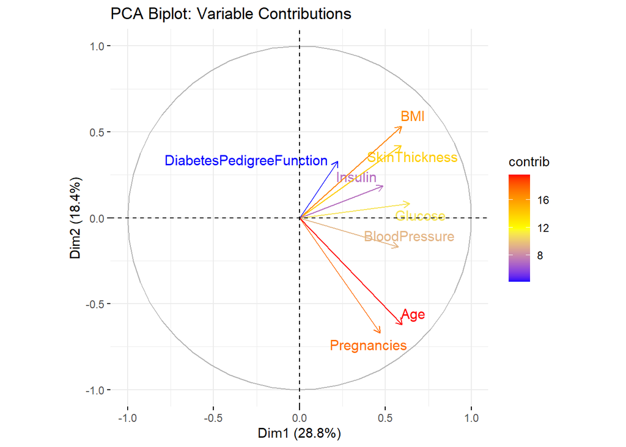

```r
# Step 4: PCA Biplot
fviz_pca_var(pca_result,
             col.var = "contrib", # Color by contributions to principal components
             gradient.cols = c("blue", "yellow", "red"),
             repel = TRUE, # Avoid overlapping text
             title = "PCA Biplot: Variable Contributions")
```

**Scree Plot**

- The first two principal components explain **47.2%** of the total variance (28.8% + 18.4%).
- Including a third component raises the explained variance to **61.3%**.
- The first two or three components can be used for dimensionality reduction as they capture most of the variability.

# 5 Clustering Analysis

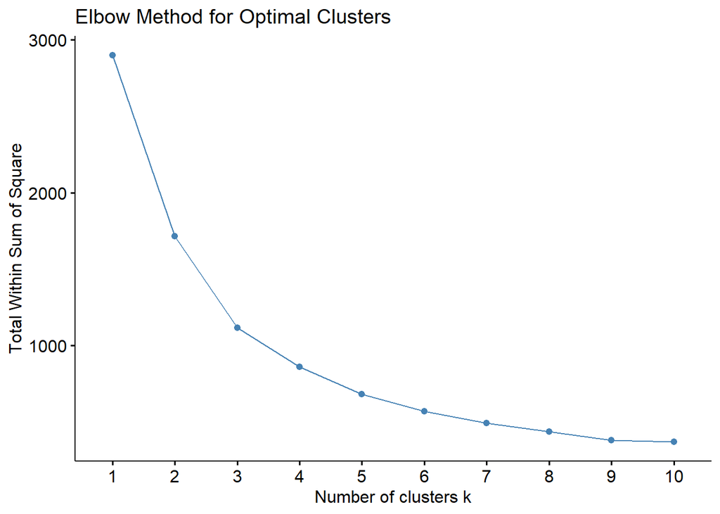

```r
library(cluster)
library(factoextra)

# Step 1: Use PCA-reduced dataset (first two components)
pca_data <- pca_result$ind$coord[, 1:2] # Coordinates of the first two principal components

# Step 2: Determine the optimal number of clusters using the Elbow Method
fviz_nbclust(pca_data, kmeans, method = "wss") +
  ggtitle("Elbow Method for Optimal Clusters")
```

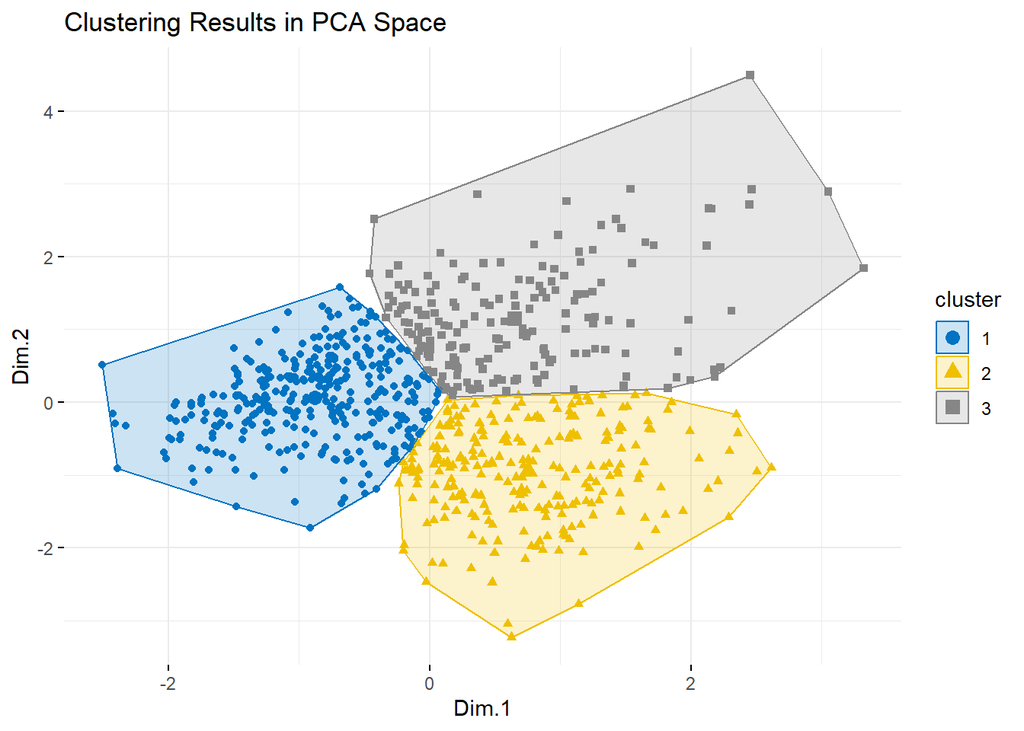

```r
# Step 3: Apply k-means clustering
set.seed(123) # Ensure reproducibility
kmeans_result <- kmeans(pca_data, centers = 3, nstart = 25) # Adjust 'centers' based on Elbow Method results

# Step 4: Visualize the clusters
fviz_cluster(kmeans_result, data = pca_data,
             geom = "point", ellipse.type = "convex",
             palette = "jco", ggtheme = theme_minimal(),
             main = "Clustering Results in PCA Space")
```

**Elbow Method**

- The Elbow Method plot suggests that the optimal number of clusters is **3**. This is where the reduction in the “Total Within Sum of Square” starts to level off significantly, indicating a balance between compactness and separation.

**Cluster Visualization**

- The clustering visualization shows **three distinct groups** plotted in the PCA-reduced space (first two principal components):
  - **Cluster 1 (Blue)**: This group represents observations with certain shared characteristics in Dim1 and Dim2.
  - **Cluster 2 (Yellow)**: Positioned distinctly, this group differs from Cluster 1 and Cluster 3 based on the PCA dimensions.
  - **Cluster 3 (Gray)**: A separate group indicating unique shared features.

# 6 Part II

## 6.1 Transform a Categorical Variable

```r
# Transform Outcome into a binary variable with an imbalanced split
data_imputed$BinaryOutcome <- ifelse(data_imputed$Outcome == 1, "Rare", "Common")

# Check the proportion of the two classes
table(data_imputed$BinaryOutcome)
```

```
Common   Rare
   500    268
```

```r
prop.table(table(data_imputed$BinaryOutcome))
```

```
   Common      Rare
0.6510417 0.3489583
```

The output indicates that the transformation of the **Outcome** variable into a **BinaryOutcome** was successful, with the following distribution:

- **Common**: 500 observations (approximately **65%** of the dataset).
- **Rare**: 268 observations (approximately **35%** of the dataset).

However, the **Rare** category constitutes more than 10% of the dataset, meaning it does not yet meet the criteria of being the smaller group (<10%).

## 6.2 Refine the Binary Variable

```r
# Refine the BinaryOutcome based on Outcome and Glucose levels
data_imputed$RefinedBinaryOutcome <- ifelse(data_imputed$Outcome == 1 & data_imputed$Glucose > 140, "Rare", "Common")

# Check the new distribution
table(data_imputed$RefinedBinaryOutcome)
```

```
Common   Rare
   636    132
```

```r
prop.table(table(data_imputed$RefinedBinaryOutcome))
```

```
  Common     Rare
0.828125 0.171875
```

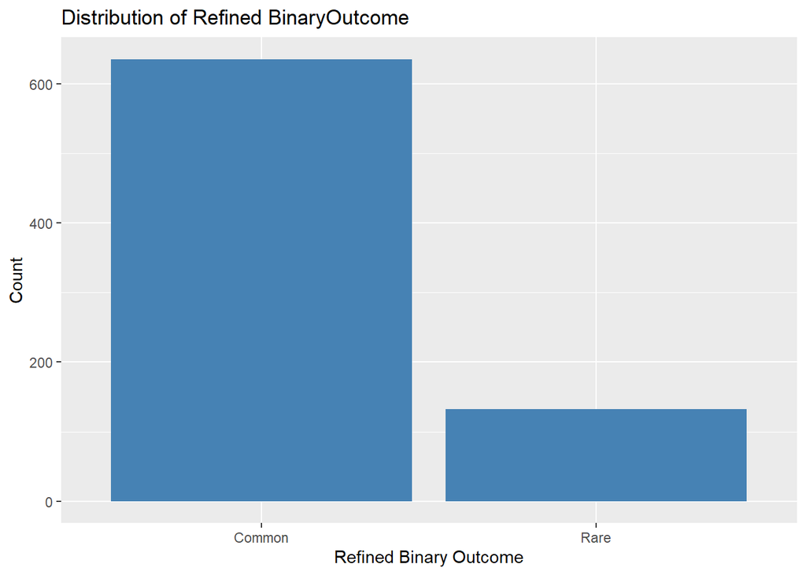

```r
# Visualize the new BinaryOutcome distribution
ggplot(data_imputed, aes(x = RefinedBinaryOutcome)) +
  geom_bar(fill = "steelblue") +
  labs(title = "Distribution of Refined BinaryOutcome", x = "Refined Binary Outcome", y = "Count")
```

The refined **BinaryOutcome** variable now has the following distribution:

- **Common**: 636 observations (~83% of the dataset).
- **Rare**: 132 observations (~17% of the dataset).

## 6.3 PCA for Refined Binary Outcome

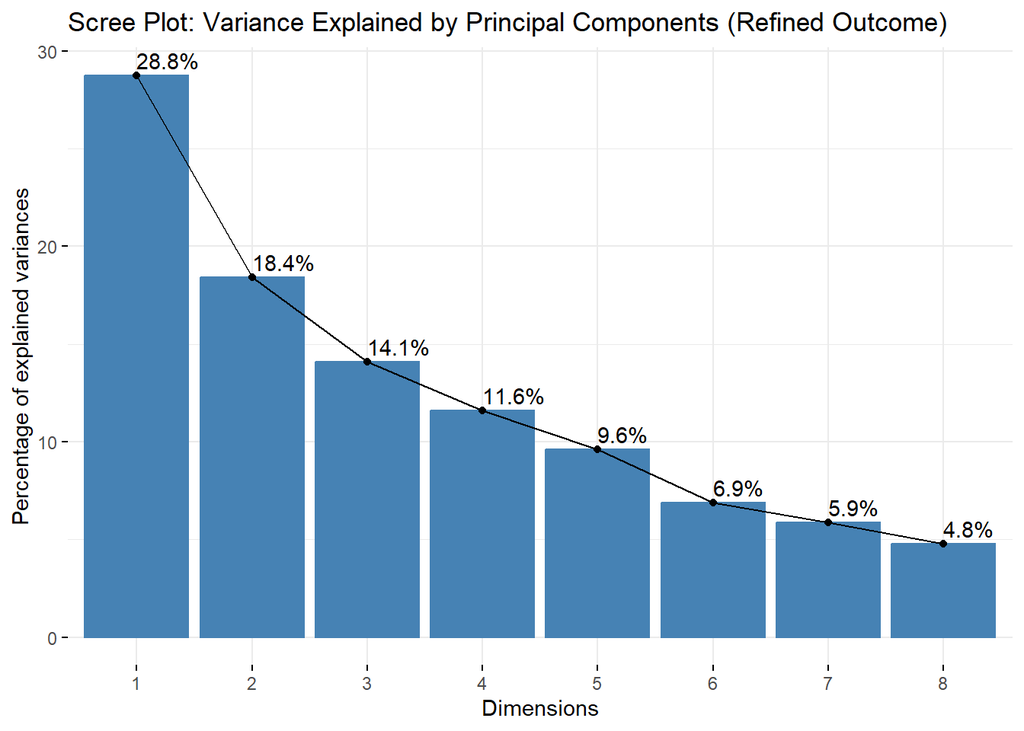

```r
# Perform PCA (reuse the standardized data from Part I)
pca_result_refined <- PCA(data_scaled, graph = FALSE)

# Scree plot to check variance explained
fviz_screeplot(pca_result_refined, addlabels = TRUE,
               title = "Scree Plot: Variance Explained by Principal Components (Refined Outcome)")
```

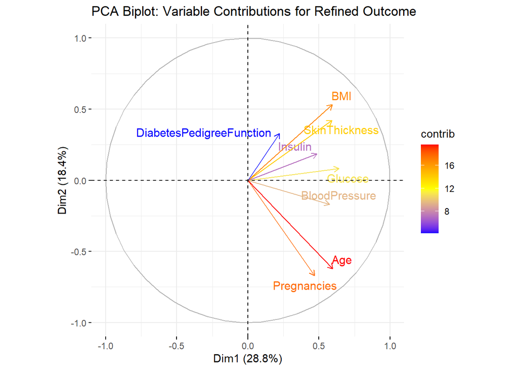

```r
# Biplot focusing on variable contributions only
fviz_pca_var(pca_result_refined,
             col.var = "contrib", # Color by contributions to principal components
             gradient.cols = c("blue", "yellow", "red"),
             repel = TRUE,       # Avoid overlapping text
             title = "PCA Biplot: Variable Contributions for Refined Outcome")
```

**Scree Plot**

- The first two principal components explain **47.2%** of the total variance (28.8% + 18.4%).
- Including a third component raises the explained variance to **61.3%**, similar to Part I.
- Conclusion: The first two or three components provide sufficient dimensionality reduction for further analysis.

**Variable Contributions (Biplot)**

Conclusion: The variables influencing the principal components align well with health metrics relevant to the refined binary outcome.

## 6.4 Clustering Analysis

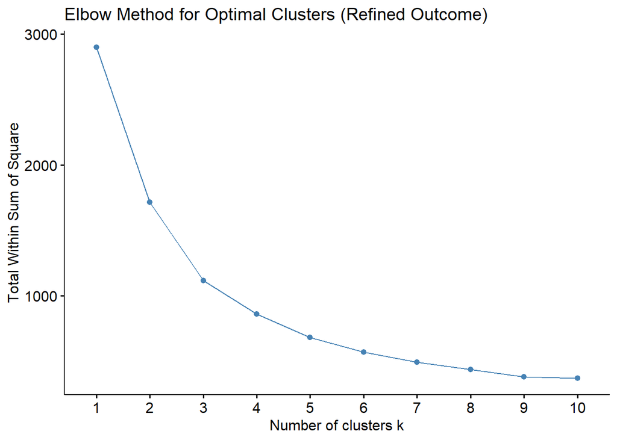

```r
# Use the first two principal components for clustering
pca_data_refined <- pca_result_refined$ind$coord[, 1:2]

# Determine the optimal number of clusters using the Elbow Method
fviz_nbclust(pca_data_refined, kmeans, method = "wss") +
  ggtitle("Elbow Method for Optimal Clusters (Refined Outcome)")
```

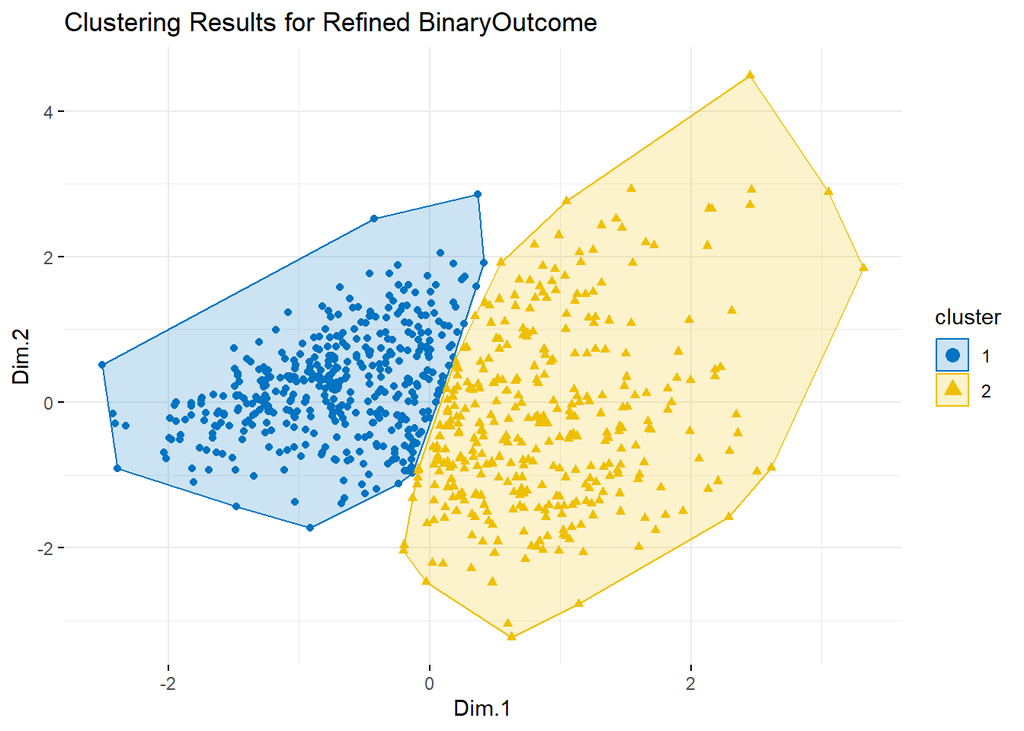

```r
# Apply k-means clustering (using 2 clusters as the refined outcome has two categories)
set.seed(123)
kmeans_refined <- kmeans(pca_data_refined, centers = 2, nstart = 25)

# Visualize the clustering results
fviz_cluster(kmeans_refined, data = pca_data_refined,
             geom = "point", ellipse.type = "convex",
             palette = "jco", ggtheme = theme_minimal(),
             main = "Clustering Results for Refined BinaryOutcome")
```

## 6.5 Compare Clusters with Refined Binary Outcome

```r
# Contingency table to compare clustering and RefinedBinaryOutcome
table(data_imputed$RefinedBinaryOutcome, kmeans_refined$cluster)
```

```
           1   2
  Common 401 235
  Rare    16 116
```

1. **Cluster 1 (Blue)**:
- Primarily consists of **Common** cases (401 observations).
- Contains only a small number of **Rare** cases (16 observations).
2. **Cluster 2 (Yellow)**:
- Contains most of the **Rare** cases (116 observations).
- Also includes a significant number of **Common** cases (235 observations).
- **Cluster Purity**:
  - Cluster 2 (Yellow) captures a majority of the **Rare** group (116 out of 132, ~88%).
  - Cluster 1 (Blue) captures a majority of the **Common** group (401 out of 636, ~63%).
- **Overlap**:
  - Some overlap exists, particularly with 235 **Common** cases falling into Cluster 2.

# 7 Final Conclusion

**Part I: Initial PCA and Clustering**

1. **PCA Results**:
- The first two principal components captured **47.2%** of the variance, effectively reducing the dataset’s dimensionality for clustering.
- Key variables contributing to variability included **Age**, **Pregnancies**, **BMI**, and **Glucose**.
2. **Clustering Analysis**:
- Using k-means clustering, three distinct clusters were identified in the PCA-reduced space.
- The clusters suggested natural groupings based on health metrics, aligning well with expectations but without specific labels.

**Part II: Binary Variable Transformation and Analysis**